# Analyses of GSE138988; GSE224858; GSE224752

## Batch Effect Correction

```r
metadata <- data.frame(Sample=sampletype, G3=g3state, Stress=forstress, Cell=Celltype)
#This is the code I used to correct batch effect. It is based on the one we used in Schneider et al. (2024), aka voyAGEr.
batch_cols <- c("G3", "Stress", "Cell") #We define which variable we want to treat as batch effects
metadata_cols <- c("Sample") #And those we dont want to treat as such
#This creates a new matrix with all our variables of interest
mmbatch <- model.matrix(reformulate(paste0("~0 + ",paste0( batch_cols,collapse = " + "))), data=metadata)
mmkeep <- model.matrix(reformulate(paste0("~0 + ",paste0( metadata_cols,collapse =  "+" ))), data=metadata)
mm <- cbind(mmkeep,mmbatch)
#Now, we apply the new model
D0 <- DGEList(2^y$E) #I use the normalised counts, but these must be "unloged". Hence the 2^
D0 <- calcNormFactors(D0)
y <- voom(D0, mm, plot = F)
```

```
## Coefficients not estimable: G3WT CellU2-OS
```

```r
fit <- lmFit(y, mm)
```

```
## Coefficients not estimable: G3WT CellU2-OS
```

```r
#Basicly, we determine what coefficients are originated from our batch variable, and we remove those across the data
beta <- fit$coefficients[,-(1:ncol(mmkeep)),drop=FALSE]
beta[is.na(beta)] <- 0 #In the case of binary variables, one of them wont have "any effect" and will thus be NA. This corrects for that step.
corrcounts_v1 <- as.matrix(y$E) - beta %*% t(mmbatch)
offset <- apply(corrcounts_v1,1,min) - apply(y$E,1,min) #This gives the offset itself that needs to be applied
corrcounts_v1 <- as.data.frame(corrcounts_v1-offset)
corrcounts_v1 <- 2^corrcounts_v1 #I prefer to unlog them, to have a dataframe of non-log CPMs, in case I need.
```

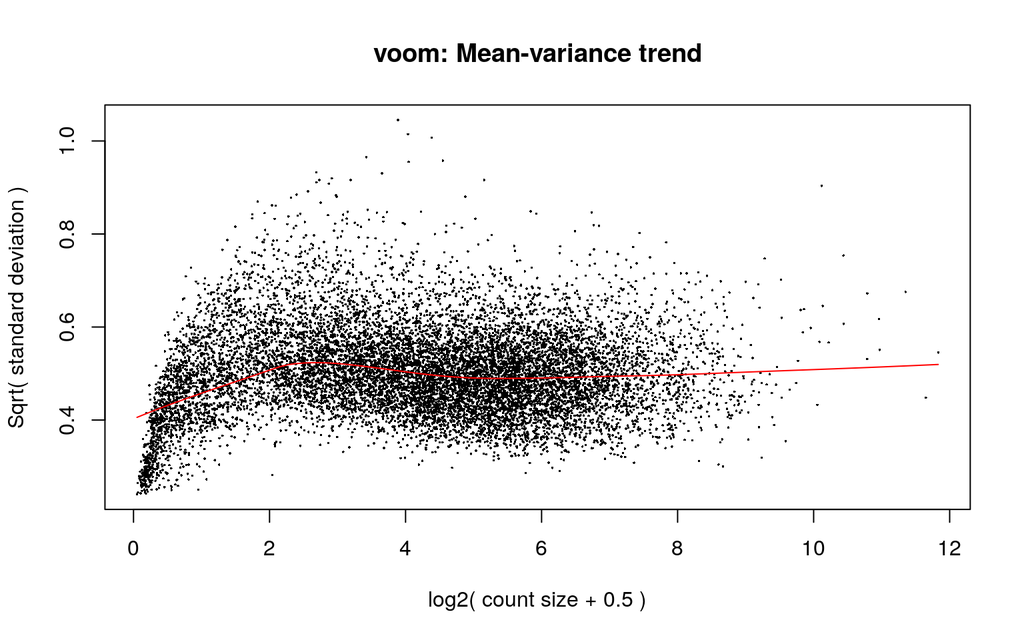

```r
# Now we simply generate new log CPM expression values, starting from the correct expression values.
mm <- model.matrix(~0+Sample, metadata)
y <- voom(corrcounts_v1, mm, plot = T)
```

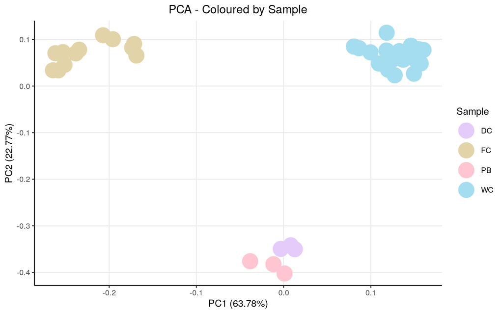

```r
#This prepares my data for the PCA
dfforpca <- y$E
dfforpca <- t(dfforpca)
dfforpca <- as.data.frame(dfforpca) # needs to be a data.frame
dfforpca <- apply(dfforpca, 2, as.numeric) # Ensure numeric
dfforpca <- as.data.frame(dfforpca) # still needs to be a data.frame

dfforpca$Sample <- sampletype
dfforpca$G3 <- g3state
dfforpca$Stress <- forstress
dfforpca$Cell <- Celltype

# PCA computation itself. I do one PCA for each variable I want to see.
pca_res <- prcomp(dfforpca[, 1:(ncol(dfforpca)-4)], scale = FALSE)

p_Sample <- autoplot(pca_res, data = dfforpca, x = 1, y = 2, colour = "Sample", size = 8) +
  theme_bw() +
  scale_colour_manual(name = "Sample", values = custom_palette) +
  ggtitle("PCA - Coloured by Sample") +
  theme(plot.title = element_text(hjust = 0.5),
        axis.line = element_line(colour = "black"),
        panel.grid.minor = element_blank(),
        panel.border = element_blank(),
        panel.background = element_blank())

p_g3 <- autoplot(pca_res, data = dfforpca, x = 1, y = 2, colour = "G3", size = 8) +
  theme_bw() +
  scale_colour_manual(name = "G3", values = custom_palette) +
  ggtitle("PCA - Coloured by G3") +
  theme(plot.title = element_text(hjust = 0.5),
        axis.line = element_line(colour = "black"),
        panel.grid.minor = element_blank(),
        panel.border = element_blank(),
        panel.background = element_blank())

p_Stress <- autoplot(pca_res, data = dfforpca, x = 1, y = 2, colour = "Stress", size = 8) +
  theme_bw() +
  scale_colour_manual(name = "Stress", values = custom_palette) +
  ggtitle("PCA - Coloured by Stress") +
  theme(plot.title = element_text(hjust = 0.5),
        axis.line = element_line(colour = "black"),
        panel.grid.minor = element_blank(),
        panel.border = element_blank(),
        panel.background = element_blank())

p_Cell <- autoplot(pca_res, data = dfforpca, x = 1, y = 2, colour = "Cell", size = 8) +
  theme_bw() +
  scale_colour_manual(name = "Cell", values = custom_palette) +
  ggtitle("PCA - Coloured by Cell") +
  theme(plot.title = element_text(hjust = 0.5),
        axis.line = element_line(colour = "black"),
        panel.grid.minor = element_blank(),
        panel.border = element_blank(),
        panel.background = element_blank())

p_Sample
```

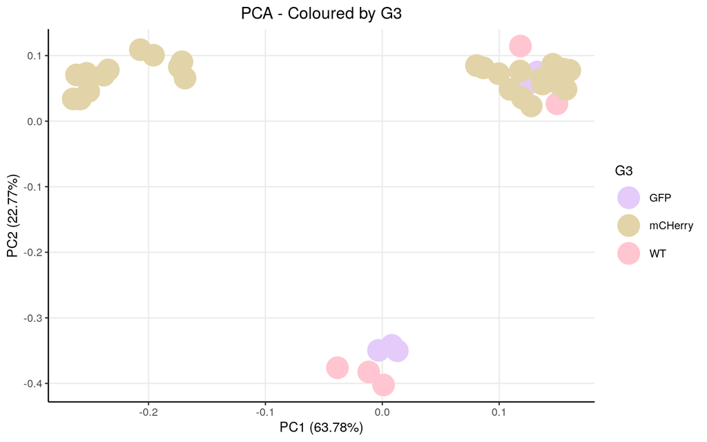

```r
p_g3
```

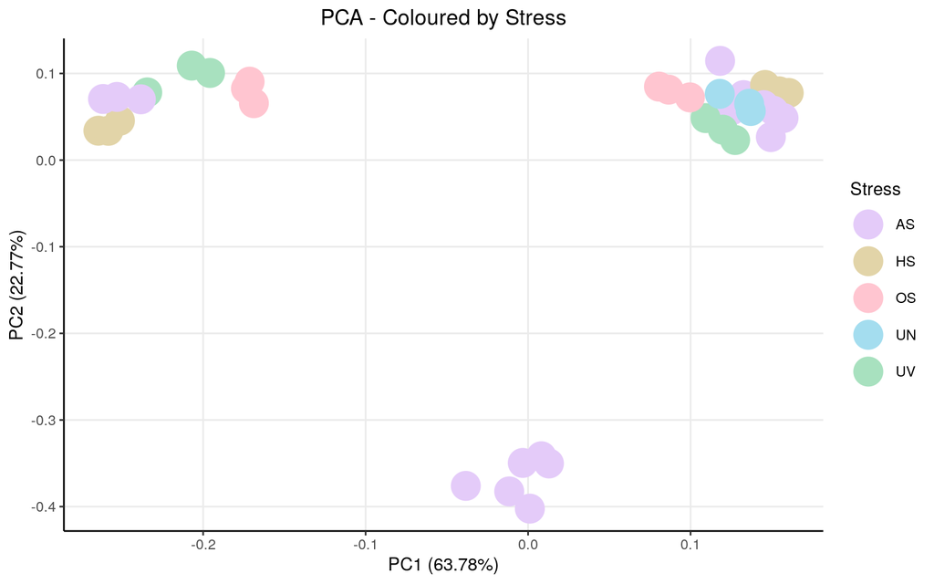

```r
p_Stress
```

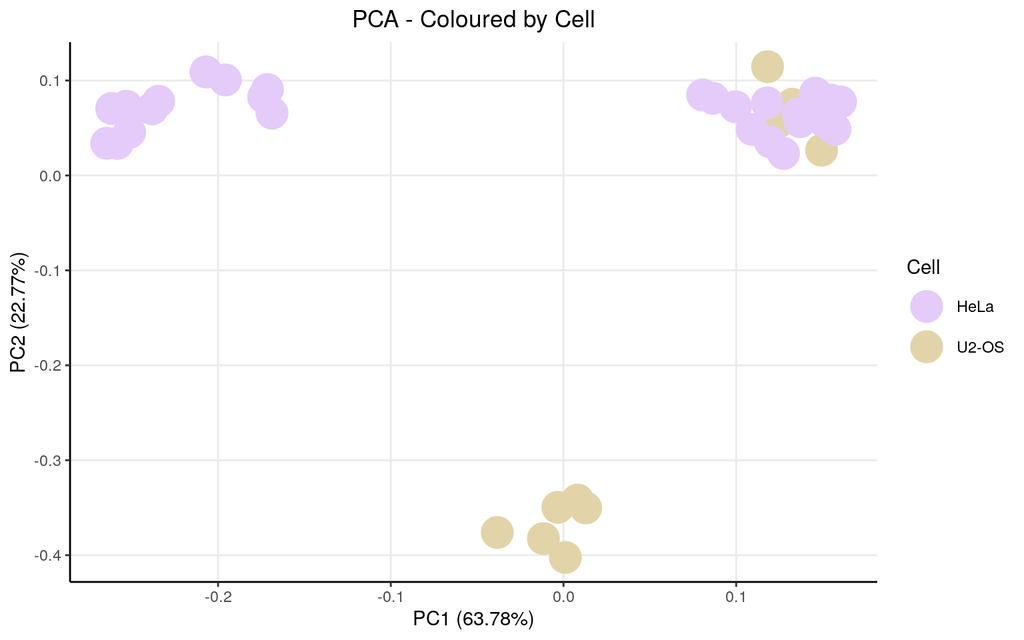

```r
p_Cell
```

```r
#in case you want to see most important genes for PCA yourself
contribs1 <- pca_res$rotation[,1]
contribs2 <- pca_res$rotation[,2]

#These are the biggest contributors to the PCA1 (right side)
(pos1genes <- sort(contribs1, decreasing=T)[1:10])
```

```
##            RMRP           RPPH1           RN7SK             7SK          MT-ND5
##      0.05246068      0.04947853      0.04458081      0.04456834      0.04390669
##         SNORD3A          MT-CYB          MT-ND4 Telomerase-vert            TERC
##      0.04309563      0.04269809      0.04238978      0.04209802      0.04196328
```

```r
#These are the biggest contributors to the PCA1 (left side)
(neg1genes <- sort(contribs1, decreasing=F)[1:10])
```

```
##      GTF2A1       BNIP2       SESN3      ZBTB41        CDK6        RO60
## -0.01969763 -0.01968347 -0.01952652 -0.01922794 -0.01910420 -0.01909405
##       ARL5B      STK38L        DCP2      OSBPL8
## -0.01908413 -0.01898248 -0.01891680 -0.01878289
```

```r
#These are the biggest contributors to the PCA2 (up side)
(pos2genes <- sort(contribs2, decreasing=T)[1:10])
```

```
##     RN7SL1     RN7SL3    RN7SL4P      RPL39      RPS29       H4C9       H3C2
## 0.06188065 0.05492947 0.04872283 0.03514478 0.03510171 0.03410809 0.03381593
##      RPS12      RPS21     H2BC11
## 0.03381454 0.03363307 0.03337921
```

```r
#These are the biggest contributors to the PCA2 (down side)
(neg2genes <- sort(contribs2, decreasing=F)[1:10])
```

```
##      MT-ND5      MT-ND6       MT-TG       MT-TR     MT-ND4L       MT-TK
## -0.04464851 -0.03944925 -0.03833748 -0.03665941 -0.03435227 -0.03295920
##      MT-ND3      MT-ND4        PLEC      MT-CYB
## -0.03162668 -0.02957315 -0.02955624 -0.02935104
```

After batch correction, as one can observe from the PCAs, our PC1 is now explained by sample type.

# PB vs SG DC

## Linear Models

Now we must perform linear model fitting.

```r
fitted <- lmFit(y, mm)
head(coef(fitted))
```

```
##          SampleDC  SampleFC  SamplePB SampleWC
## 7SK      6.530074 0.7822469 1.0352877 7.120336
## A1BG-AS1 3.956324 1.2448349 3.9026991 3.071652
## A2M      2.206804 1.3085752 1.6515973 2.114610
## A2MP1    1.379014 1.0505162 0.9432595 1.740534
## A4GALT   2.106702 1.7237033 2.3110116 2.216899
## AAAS     5.103303 4.8985558 4.5380227 6.192766
```

```r
#next we measure contrasts between groups (log-fold change is obtained from these fitted linear models)
contr<- makeContrasts(SampleDC         - SampleWC, levels = colnames(coef(fitted)))

#next we estimate the contrast for each gene
tmp <- contrasts.fit(fitted, contr)


#use empirical bayes smoothing of standard erros (shrinks extreme standard erros)
tmp <- eBayes(tmp)
top.table <- topTable(tmp, sort.by = "logFC", n = Inf)
DEGenes <- top.table
ndegs=20
```

## Volcano

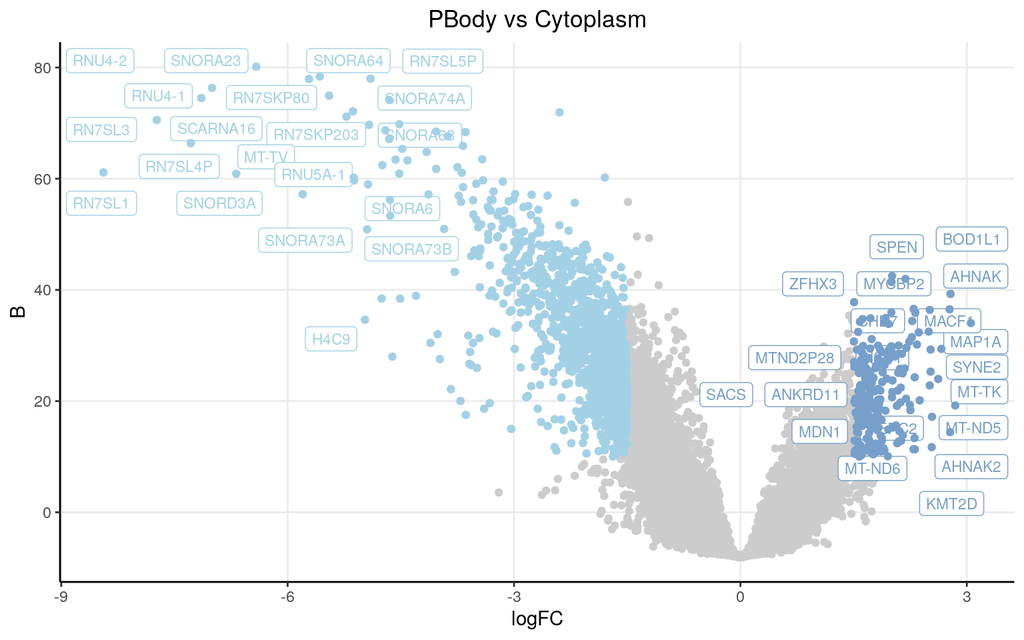

```r
upmarkers <- as.data.frame(DEGenes[DEGenes$logFC>1.5 & DEGenes$B>10,] )
downmarkers <- as.data.frame(DEGenes[DEGenes$logFC< -1.5 & DEGenes$B>10,] )

ggplot(data=DEGenes,
                 aes(x=logFC,
                     y=  B)) +
  geom_point(color="#CCCCCC")+
  theme_bw() +
  theme(axis.line = element_line(colour = "black"),
        panel.grid.minor = element_blank(),
        panel.border = element_blank(),
        panel.background = element_blank()) +
  ggtitle("PBody vs Cytoplasm")+
  theme(plot.title = element_text(hjust = 0.5)) +
  geom_label_repel(upmarkers[1:ndegs,] , mapping=aes(label=row.names(upmarkers)[1:ndegs]),size=3,point.padding=-0.5, color="#769fca",max.overlaps = 20)+
  geom_label_repel(downmarkers[1:ndegs,] , mapping=aes(label=row.names(downmarkers)[1:ndegs]),size=3,point.padding=-0.5, color="#a2d1e6",max.overlaps = 20)+
  geom_point(data=upmarkers, aes(x=logFC, y=  B), color="#769fca")+
  geom_point(data=downmarkers, aes(x=logFC, y=  B), color="#a2d1e6")
```

```r
dc_t <- data.frame(Gene=row.names(DEGenes), dc_t=DEGenes$t)
```

# PB vs SG Fanci

## Linear Models

Now we must perform linear model fitting.

```r
fitted <- lmFit(y, mm)
head(coef(fitted))
```

```
##          SampleDC  SampleFC  SamplePB SampleWC
## 7SK      6.530074 0.7822469 1.0352877 7.120336
## A1BG-AS1 3.956324 1.2448349 3.9026991 3.071652
## A2M      2.206804 1.3085752 1.6515973 2.114610
## A2MP1    1.379014 1.0505162 0.9432595 1.740534
## A4GALT   2.106702 1.7237033 2.3110116 2.216899
## AAAS     5.103303 4.8985558 4.5380227 6.192766
```

```r
#next we measure contrasts between groups (log-fold change is obtained from these fitted linear models)
contr<- makeContrasts(SampleFC         - SampleWC, levels = colnames(coef(fitted)))

#next we estimate the contrast for each gene
tmp <- contrasts.fit(fitted, contr)


#use empirical bayes smoothing of standard erros (shrinks extreme standard erros)
tmp <- eBayes(tmp)
top.table <- topTable(tmp, sort.by = "logFC", n = Inf)
DEGenes <- top.table
ndegs=20
```

## Volcano

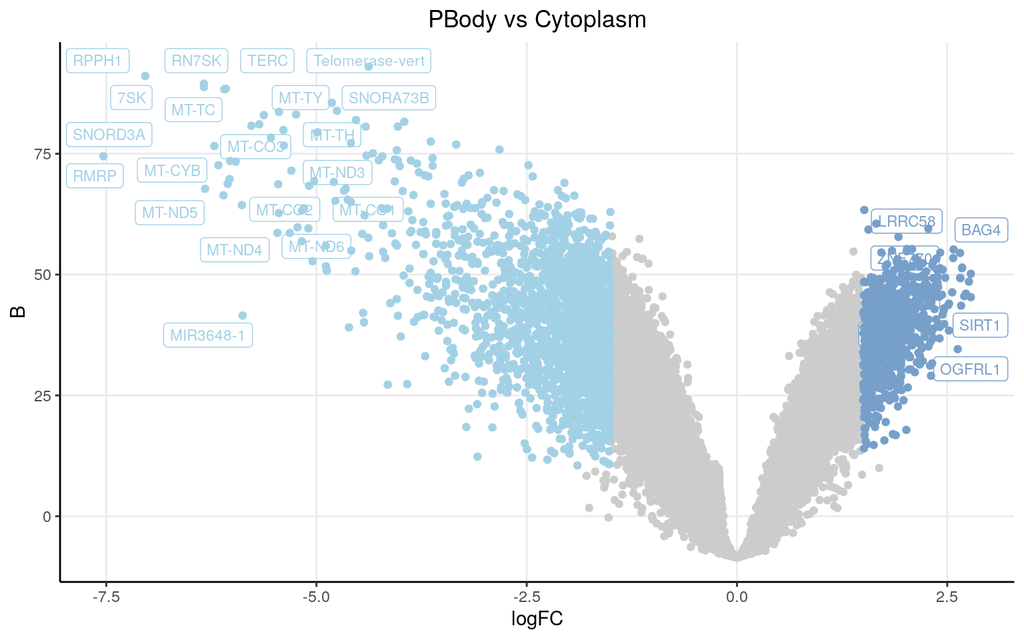

```r
upmarkers <- as.data.frame(DEGenes[DEGenes$logFC>1.5 & DEGenes$B>10,] )
downmarkers <- as.data.frame(DEGenes[DEGenes$logFC< -1.5 & DEGenes$B>10,] )

ggplot(data=DEGenes,
                 aes(x=logFC,
                     y=  B)) +
  geom_point(color="#CCCCCC")+
  theme_bw() +
  theme(axis.line = element_line(colour = "black"),
        panel.grid.minor = element_blank(),
        panel.border = element_blank(),
        panel.background = element_blank()) +
  ggtitle("PBody vs Cytoplasm")+
  theme(plot.title = element_text(hjust = 0.5)) +
  geom_label_repel(upmarkers[1:ndegs,] , mapping=aes(label=row.names(upmarkers)[1:ndegs]),size=3,point.padding=-0.5, color="#769fca",max.overlaps = 20)+
  geom_label_repel(downmarkers[1:ndegs,] , mapping=aes(label=row.names(downmarkers)[1:ndegs]),size=3,point.padding=-0.5, color="#a2d1e6",max.overlaps = 20)+
  geom_point(data=upmarkers, aes(x=logFC, y=  B), color="#769fca")+
  geom_point(data=downmarkers, aes(x=logFC, y=  B), color="#a2d1e6")
```

```r
fc_t <- data.frame(Gene=row.names(DEGenes), fc_t=DEGenes$t)
```

# Comparisons

Comparing the methods once again.

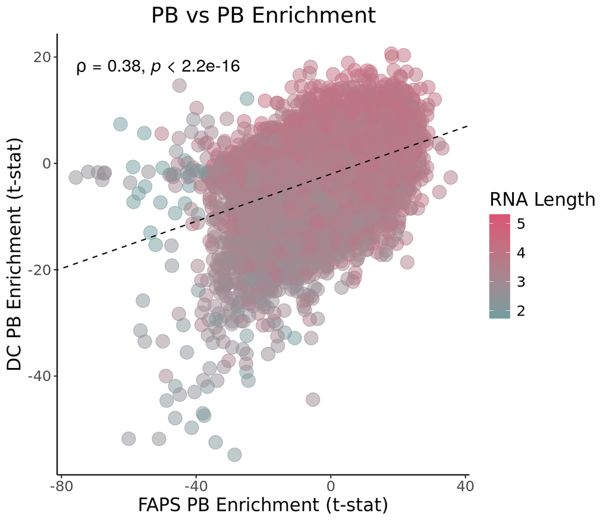

```r
tstable <- merge(dc_t, fc_t, by="Gene")
tstable <- merge(tstable, genelength, by="Gene")
smooth.SG <- lm(dc_t~(fc_t), tstable)

# Calculate the Spearman correlation coefficient
spearman_corr <- cor(tstable$dc_t, (tstable$fc_t), method = "spearman")

ggplot(tstable, aes(y=dc_t, x=(fc_t))) + geom_point(aes(color=log10(Length)), alpha=0.5, size=5) +   theme_bw()+
 ylab("DC PB Enrichment (t-stat)") + xlab("FAPS PB Enrichment (t-stat)") + scale_colour_gradient(low="black", high = "Red")+
  theme(axis.line = element_line(colour = "black"),
        panel.grid.minor = element_blank(),
        panel.border = element_blank(),
        panel.background = element_blank()) +
  geom_abline(slope=smooth.SG$coefficients[2], intercept = smooth.SG$coefficients[1], linetype = "dashed")+
  theme(plot.title = element_text(hjust = 0.5))  + ggtitle("PB vs PB Enrichment")+
  scale_colour_gradient(low="#729EA1", high = "#DB5375")+
  labs(colour = "RNA Length") + stat_cor(method = "spearman", cor.coef.name = "rho", size=5)+ theme(panel.grid.major = element_blank(), panel.grid.minor = element_blank())+theme(text=element_text(size=15,  family="Arial MS"))
```

```r
write.table(tstable,"~/Projects/StressGranules/SGPAPER/FAPSvsDC.txt")
```

# Only Hela Cells

```r
 #Get the table of read counts by indicating the path to the file. This file is what we obtained from the running featureCounts.
fanci <- read.table("~/Projects/StressGranules/SG_Transcriptome/FANCI/TrimmedSamples/alignment_STAR/featureCounts_Results.txt", header = T)[,-c(2:6)]

#Loading up our biomart file, obtained from Ensembl, where we have the equivalence between Ensembl IDs and HGNC names
biomart <- fread("~/biomart.txt")[,-1]


colnames(fanci)[1] <- "ensembl_gene_id_version"
colnames(biomart) <- c("ensembl_gene_id_version", "hgnc_symbol")
eltable <- merge(fanci,biomart,by = "ensembl_gene_id_version", all= TRUE) #this creates a table with both ensemble ids and HGNC codes.

eltable <- subset(eltable, hgnc_symbol!="")#this removes reads that dont have a corresponding hgnc symbol.
eltable$ensembl_gene_id_version <- NULL
read.counts <- eltable %>%
  group_by(hgnc_symbol) %>%
  summarise(across(everything(), sum, na.rm = TRUE))

read.counts <- as.data.frame(read.counts)
read.counts <- read.counts[,c(1,11:13,23:28)]


newpbody1 <- fread("~/Projects/StressGranules/SG_Transcriptome/P_Bodies/GSE224752_HEL_Counts.txt")
colnames(newpbody1) <- c("hgnc_symbol","HPB1", "HPB2", "HCY1", "HCY2")

read.counts1 <- newpbody1 %>%
  group_by(hgnc_symbol) %>%
  summarise(across(everything(), sum, na.rm = TRUE))

stress.read.counts <- merge(read.counts, read.counts1, by="hgnc_symbol")

stress.read.counts <- as.data.frame(stress.read.counts)
row.names(stress.read.counts) <- stress.read.counts$hgnc_symbol
stress.read.counts$hgnc_symbol <- NULL
```

## Filtration

### *Before Filtration*

Let us begin with the filtration. Personally, I find that its easier to do visually. I am aware that my filtration is more violent than most. Usually, from RNA-Seq experiments, we commonly obtain bi-modal distributions, with the first mode corresponding to lowly expressed genes. I remove these by cutting just before the second mode. This time, I opted to also observe every sample type by itself.

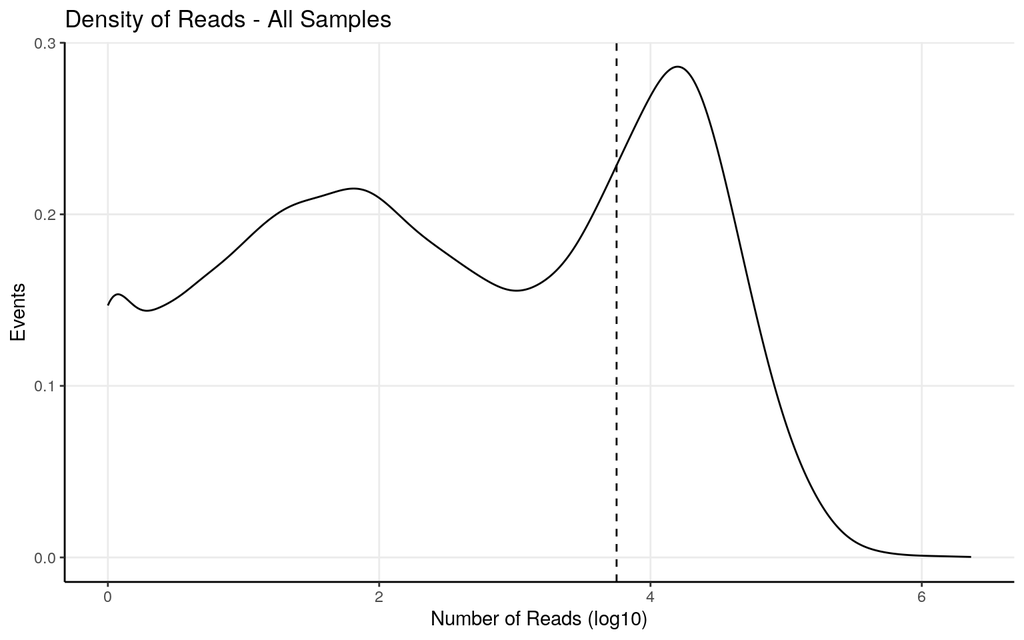

```r
alternew <- log10(rowSums(stress.read.counts))
alternew <- as.data.frame(alternew)


alternew.sg <- log10(rowSums(stress.read.counts[,1:9]))
alternew.sg <- as.data.frame(alternew.sg)

alternew.pb <- log10(rowSums(stress.read.counts[,10:13]))
alternew.pb <- as.data.frame(alternew.pb)


ggplot(alternew, aes(x=alternew)) + geom_density() + theme_bw() + geom_vline(xintercept = 3.75, linetype = "dashed") + ylab("Events") + xlab("Number of Reads (log10)") +
  theme(axis.line = element_line(colour = "black"),
        panel.grid.minor = element_blank(),
        panel.border = element_blank(),
        panel.background = element_blank()) + ggtitle("Density of Reads - All Samples")
```

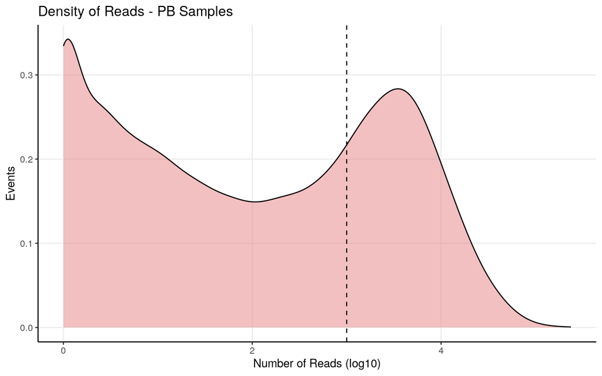

```r
ggplot(alternew.pb, aes(x=alternew.pb)) + geom_density(fill="#e88184", alpha=0.5) + theme_bw() + geom_vline(xintercept = 3, linetype = "dashed") + ylab("Events") + xlab("Number of Reads (log10)") +
  theme(axis.line = element_line(colour = "black"),
        panel.grid.minor = element_blank(),
        panel.border = element_blank(),
        panel.background = element_blank()) + ggtitle("Density of Reads - PB Samples")
```

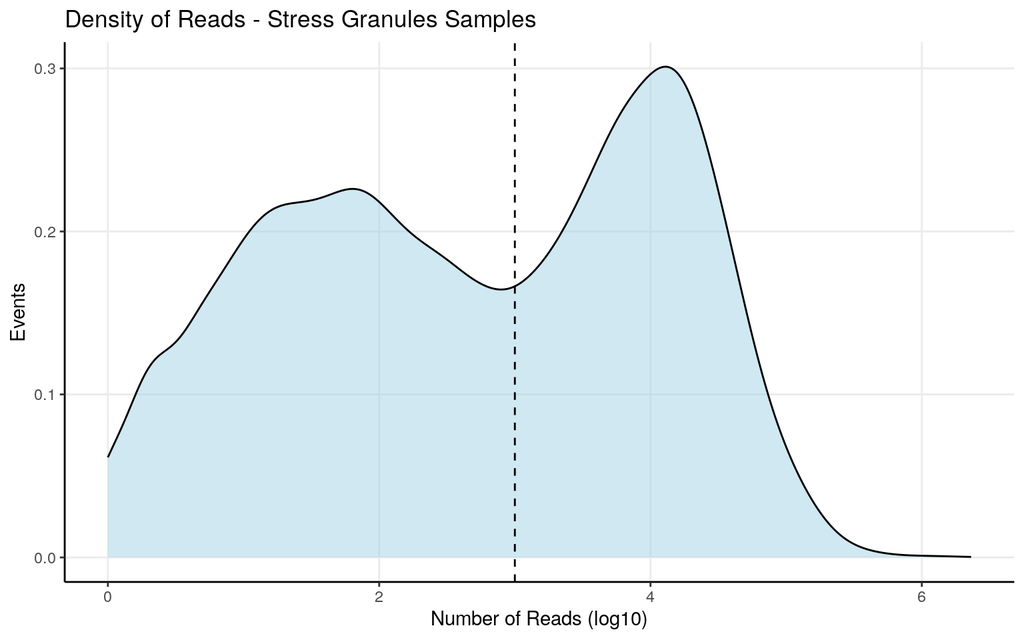

```r
ggplot(alternew.sg, aes(x=alternew.sg)) + geom_density(fill="#a2d1e6", alpha=0.5) + theme_bw() + geom_vline(xintercept = 3, linetype = "dashed") + ylab("Events") + xlab("Number of Reads (log10)") +
  theme(axis.line = element_line(colour = "black"),
        panel.grid.minor = element_blank(),
        panel.border = element_blank(),
        panel.background = element_blank()) + ggtitle("Density of Reads - Stress Granules Samples")
```

### *After Filtration*

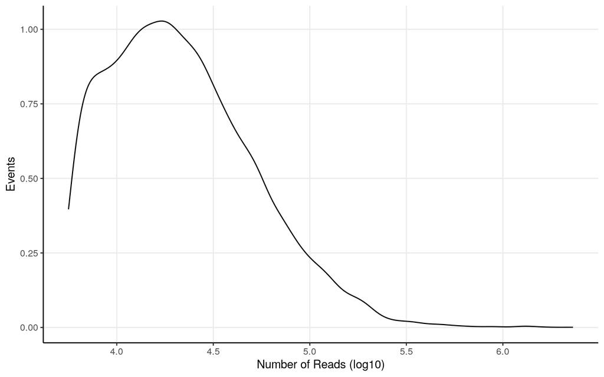

```r
filterednew <- subset(stress.read.counts, alternew>3.75)
filterednew.sg <- subset(stress.read.counts, alternew.sg>3)
filterednew.pb <- subset(stress.read.counts, alternew.pb>3)


#after cutting, its a good idea to visualize again
falternew <- log10(rowSums(filterednew))
falternew <- as.data.frame(falternew)
ggplot(falternew, aes(x=falternew)) + geom_density() + theme_bw() + ylab("Events") + xlab("Number of Reads (log10)") +
  theme(axis.line = element_line(colour = "black"),
        panel.grid.minor = element_blank(),
        panel.border = element_blank(),
        panel.background = element_blank())
```

```r
#lets save the genes which we maintain
impgenes <- c(row.names(falternew))
impgenes.sg <- c(row.names(filterednew.sg))
impgenes.pb<- c(row.names(filterednew.pb))


#Now we need to select only the rows which have those genes.
finaltable <- stress.read.counts[row.names(stress.read.counts)%in%impgenes,]
finaltable <- finaltable[row.names(finaltable)%in%impgenes.sg,]
finaltable <- finaltable[row.names(finaltable)%in%impgenes.pb,]
```

## Matrices

Good! Now we can proceed by designing our matrices.

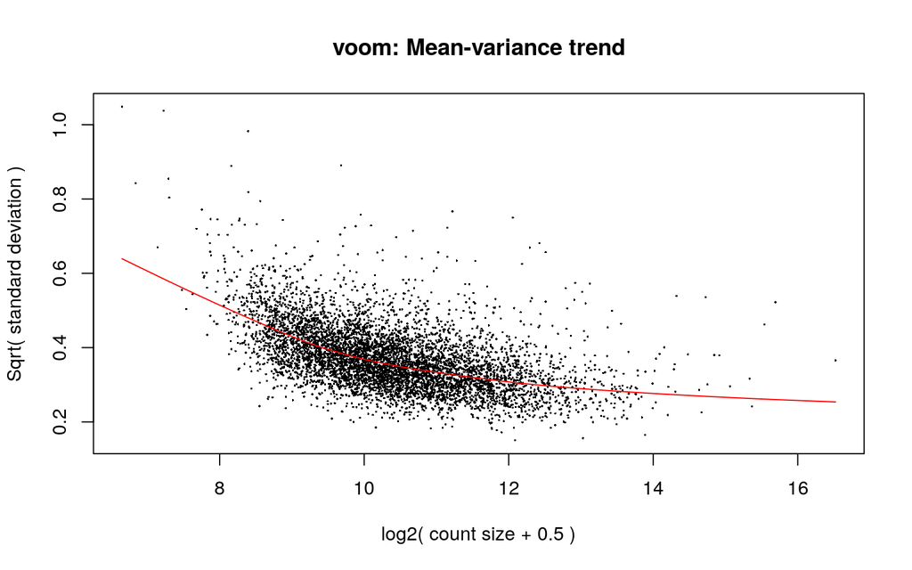

```r
sampletype <- c(rep("SG",3), rep("WC",6), rep("PB",2), rep("WC",2))
g3state <- c(rep("mCHerry",9), rep("WT",4))
forstress <- c(rep("AS",3),rep("AS",3), rep("UN",3), rep("UN",4))



metadata <- data.frame(Sample=sampletype, G3=g3state, Stress=forstress)

#To be able to use Voom, we must first convert our read count table into a special DGE object.
D0 <- DGEList(finaltable)

#for the others, we need to select only relevant columns.

#Then we calculate the normalization factors.
#Bear in mind this step calculates the normalization factors, but does not normalize itself.
D0 <- calcNormFactors(D0)


#Now we do our matrix itself
mm <- model.matrix(~0+Sample+G3+Stress, metadata)

#and now we normalize. This step also turns our counts into log2-counts per million.
y <- voom(D0, mm, plot = T)
```

## Normalisation

For normalisation I convert the read counts into log2CPMs. Its a good way to visualize how the reads are.

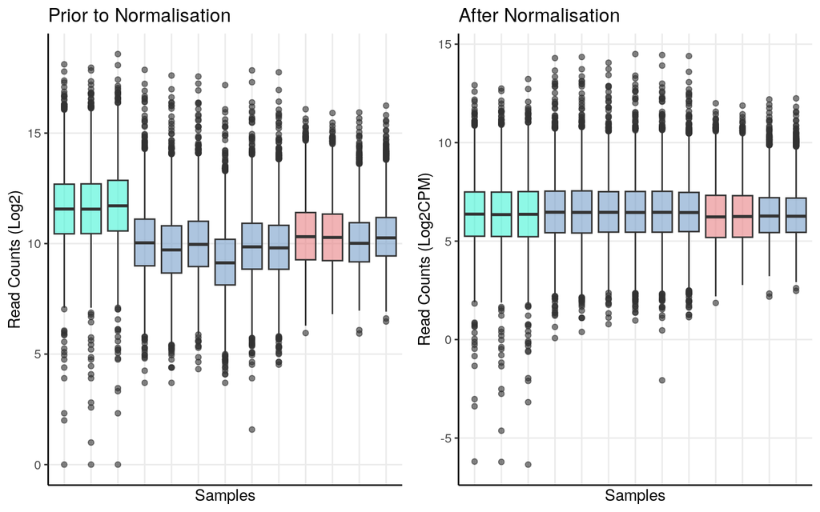

```r
dfforboxy <- finaltable

orderforplots <- sampletype
colouring <- data.frame(Sample=colnames(dfforboxy), Types=orderforplots)
dfforboxy <- reshape2::melt(dfforboxy)
colnames(dfforboxy) <- c("Sample", "Expression")
dfforboxy <- merge(dfforboxy, colouring, by="Sample")
prenorm <- ggplot(dfforboxy, aes(x=Sample, y=(log2(Expression+1)), fill=Types)) + geom_boxplot(alpha=0.6) + theme_bw() + ylab("Read Counts (Log2)") + xlab("Samples") + scale_fill_manual(name = "Sample Type", values = c("#43F3D5", "#769fca", "#e88184", "#de425b"), labels=unique(sampletype), breaks =unique(sampletype)) +
  theme(axis.line = element_line(colour = "black"),
        panel.grid.minor = element_blank(),
        panel.border = element_blank(),
        panel.background = element_blank(),
        axis.text.x=element_blank(),
        axis.ticks.x=element_blank(),
        legend.position = "None") + ggtitle("Prior to Normalisation")

dfforboxy <- y$E
dfforboxy <- reshape2::melt(dfforboxy)
dfforboxy <- dfforboxy[,-1]
colnames(dfforboxy) <- c("Sample", "Expression")
dfforboxy <- merge(dfforboxy, colouring, by="Sample")
postnorm <- ggplot(dfforboxy, aes(x=Sample, y=Expression, fill=Types)) + geom_boxplot(alpha=0.6) + theme_bw() + ylab("Read Counts (Log2CPM)") + xlab("Samples") + scale_fill_manual(name = "Sample Type", values = c("#43F3D5", "#769fca", "#e88184", "#de425b"), labels=unique(sampletype), breaks =unique(sampletype)) +
  theme(axis.line = element_line(colour = "black"),
        panel.grid.minor = element_blank(),
        panel.border = element_blank(),
        panel.background = element_blank(),
        axis.text.x=element_blank(),
        axis.ticks.x=element_blank(),
        legend.position = "None") + ggtitle("After Normalisation")

ggarrange(prenorm, postnorm, nrow=1)
```

## PCA

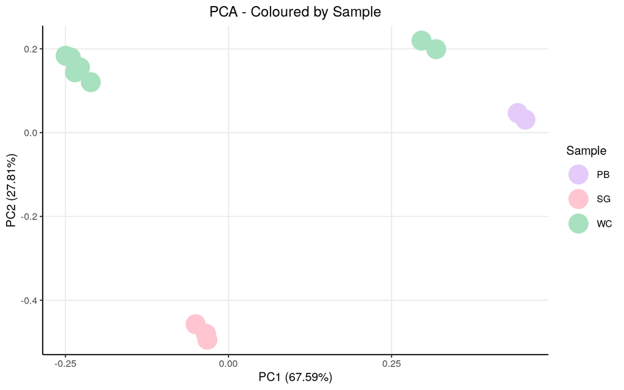

```r
# Define color palette
custom_palette <- qualitative_hcl(5, palette = "Pastel")
custom_palette <- sample(custom_palette, 5)

#This prepares my data for the PCA
dfforpca <- y$E
dfforpca <- t(dfforpca)
dfforpca <- as.data.frame(dfforpca) # needs to be a data.frame
dfforpca <- apply(dfforpca, 2, as.numeric) # Ensure numeric
dfforpca <- as.data.frame(dfforpca) # still needs to be a data.frame

dfforpca$Sample <- sampletype
dfforpca$G3 <- g3state
dfforpca$Stress <- forstress

# PCA computation itself. I do one PCA for each variable I want to see.
pca_res <- prcomp(dfforpca[, 1:(ncol(dfforpca)-3)], scale = FALSE)

p_Sample <- autoplot(pca_res, data = dfforpca, x = 1, y = 2, colour = "Sample", size = 8) +
  theme_bw() +
  scale_colour_manual(name = "Sample", values = custom_palette) +
  ggtitle("PCA - Coloured by Sample") +
  theme(plot.title = element_text(hjust = 0.5),
        axis.line = element_line(colour = "black"),
        panel.grid.minor = element_blank(),
        panel.border = element_blank(),
        panel.background = element_blank())

p_g3 <- autoplot(pca_res, data = dfforpca, x = 1, y = 2, colour = "G3", size = 8) +
  theme_bw() +
  scale_colour_manual(name = "G3", values = custom_palette) +
  ggtitle("PCA - Coloured by G3") +
  theme(plot.title = element_text(hjust = 0.5),
        axis.line = element_line(colour = "black"),
        panel.grid.minor = element_blank(),
        panel.border = element_blank(),
        panel.background = element_blank())

p_Stress <- autoplot(pca_res, data = dfforpca, x = 1, y = 2, colour = "Stress", size = 8) +
  theme_bw() +
  scale_colour_manual(name = "Stress", values = custom_palette) +
  ggtitle("PCA - Coloured by Stress") +
  theme(plot.title = element_text(hjust = 0.5),
        axis.line = element_line(colour = "black"),
        panel.grid.minor = element_blank(),
        panel.border = element_blank(),
        panel.background = element_blank())


p_Sample
```

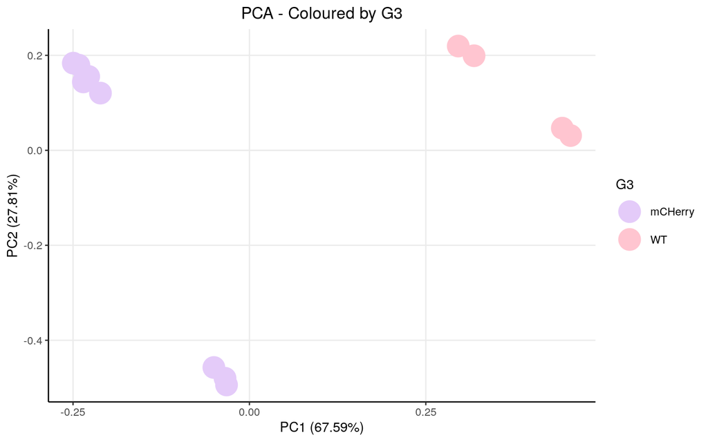

```r
p_g3
```

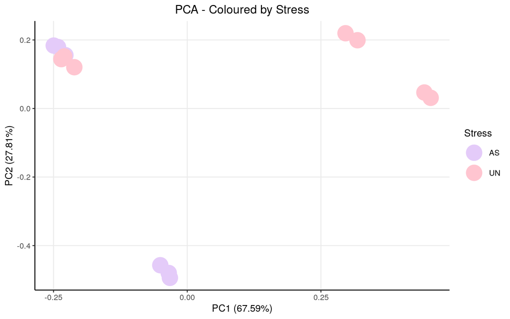

```r
p_Stress
```

```r
#in case you want to see most important genes for PCA yourself
contribs1 <- pca_res$rotation[,1]
contribs2 <- pca_res$rotation[,2]

#These are the biggest contributors to the PCA1 (right side)
(pos1genes <- sort(contribs1, decreasing=T)[1:10])
```

```
##    MT-RNR2     KBTBD8     CAVIN2 OTUD6B-AS1     CREBRF     GPR158       CD47
## 0.04680214 0.04440574 0.04358543 0.04104668 0.04038965 0.03983293 0.03923090
##     LSM14A   C21orf91     TOPORS
## 0.03739227 0.03620458 0.03495401
```

```r
#These are the biggest contributors to the PCA1 (left side)
(neg1genes <- sort(contribs1, decreasing=F)[1:10])
```

```
##       NEAT1       LAMA5       KMT2D        PLEC      RNF213        FASN
## -0.06419749 -0.05241614 -0.05130134 -0.04862939 -0.04477743 -0.04314909
##     SLC16A3        NFIC       HCFC1      SLC7A5
## -0.04217864 -0.04193784 -0.04103450 -0.04066818
```

```r
#These are the biggest contributors to the PCA2 (up side)
(pos2genes <- sort(contribs2, decreasing=T)[1:10])
```

```
##    MT-RNR2     RIPOR3     FERMT3       CTSW     MT-ND2    MT-ATP6     MT-CYB
## 0.10837055 0.10100197 0.08930949 0.08085143 0.08028987 0.07621505 0.07574493
##     MT-CO2     MT-ND5     MT-ND6
## 0.07545571 0.07386267 0.07373666
```

```r
#These are the biggest contributors to the PCA2 (down side)
(neg2genes <- sort(contribs2, decreasing=F)[1:10])
```

```
##       SESN3      GTF2A1        ADNP        CDK6       NR3C1      LRRC58
## -0.03973196 -0.03360944 -0.03134162 -0.03087070 -0.03077921 -0.02859496
##      ARID5B        ELK4      ZNF664      KLHL11
## -0.02851433 -0.02846566 -0.02779073 -0.02770800
```

## Batch Effect Correction

```r
metadata <- data.frame(Sample=sampletype, G3=g3state, Stress=forstress)
#This is the code I used to correct batch effect. It is based on the one we used in Schneider et al. (2024), aka voyAGEr.
batch_cols <- c("G3", "Stress") #We define which variable we want to treat as batch effects
metadata_cols <- c("Sample") #And those we dont want to treat as such
#This creates a new matrix with all our variables of interest
mmbatch <- model.matrix(reformulate(paste0("~0 + ",paste0( batch_cols,collapse = " + "))), data=metadata)
mmkeep <- model.matrix(reformulate(paste0("~0 + ",paste0( metadata_cols,collapse =  "+" ))), data=metadata)
mm <- cbind(mmkeep,mmbatch)
#Now, we apply the new model
D0 <- DGEList(2^y$E) #I use the normalised counts, but these must be "unloged". Hence the 2^
D0 <- calcNormFactors(D0)
y <- voom(D0, mm, plot = F)
```

```
## Coefficients not estimable: G3WT
```

```r
fit <- lmFit(y, mm)
```

```
## Coefficients not estimable: G3WT
```

```r
#Basicly, we determine what coefficients are originated from our batch variable, and we remove those across the data
beta <- fit$coefficients[,-(1:ncol(mmkeep)),drop=FALSE]
beta[is.na(beta)] <- 0 #In the case of binary variables, one of them wont have "any effect" and will thus be NA. This corrects for that step.
corrcounts_v1 <- as.matrix(y$E) - beta %*% t(mmbatch)
offset <- apply(corrcounts_v1,1,min) - apply(y$E,1,min) #This gives the offset itself that needs to be applied
corrcounts_v1 <- as.data.frame(corrcounts_v1-offset)
corrcounts_v1 <- 2^corrcounts_v1 #I prefer to unlog them, to have a dataframe of non-log CPMs, in case I need.
```

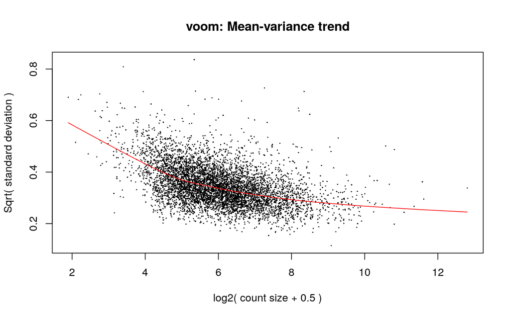

```r
# Now we simply generate new log CPM expression values, starting from the correct expression values.
mm <- model.matrix(~0+Sample, metadata)
y <- voom(corrcounts_v1, mm, plot = T)
```

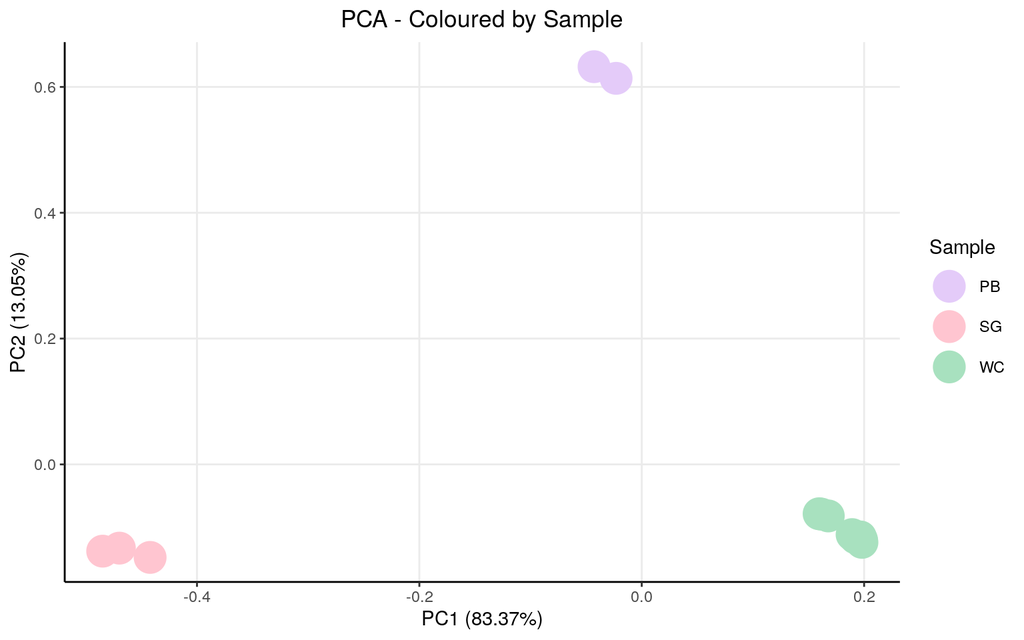

```r
#This prepares my data for the PCA
dfforpca <- y$E
dfforpca <- t(dfforpca)
dfforpca <- as.data.frame(dfforpca) # needs to be a data.frame
dfforpca <- apply(dfforpca, 2, as.numeric) # Ensure numeric
dfforpca <- as.data.frame(dfforpca) # still needs to be a data.frame

dfforpca$Sample <- sampletype
dfforpca$G3 <- g3state
dfforpca$Stress <- forstress

# PCA computation itself. I do one PCA for each variable I want to see.
pca_res <- prcomp(dfforpca[, 1:(ncol(dfforpca)-4)], scale = FALSE)

p_Sample <- autoplot(pca_res, data = dfforpca, x = 1, y = 2, colour = "Sample", size = 8) +
  theme_bw() +
  scale_colour_manual(name = "Sample", values = custom_palette) +
  ggtitle("PCA - Coloured by Sample") +
  theme(plot.title = element_text(hjust = 0.5),
        axis.line = element_line(colour = "black"),
        panel.grid.minor = element_blank(),
        panel.border = element_blank(),
        panel.background = element_blank())

p_g3 <- autoplot(pca_res, data = dfforpca, x = 1, y = 2, colour = "G3", size = 8) +
  theme_bw() +
  scale_colour_manual(name = "G3", values = custom_palette) +
  ggtitle("PCA - Coloured by G3") +
  theme(plot.title = element_text(hjust = 0.5),
        axis.line = element_line(colour = "black"),
        panel.grid.minor = element_blank(),
        panel.border = element_blank(),
        panel.background = element_blank())

p_Stress <- autoplot(pca_res, data = dfforpca, x = 1, y = 2, colour = "Stress", size = 8) +
  theme_bw() +
  scale_colour_manual(name = "Stress", values = custom_palette) +
  ggtitle("PCA - Coloured by Stress") +
  theme(plot.title = element_text(hjust = 0.5),
        axis.line = element_line(colour = "black"),
        panel.grid.minor = element_blank(),
        panel.border = element_blank(),
        panel.background = element_blank())


p_Sample
```

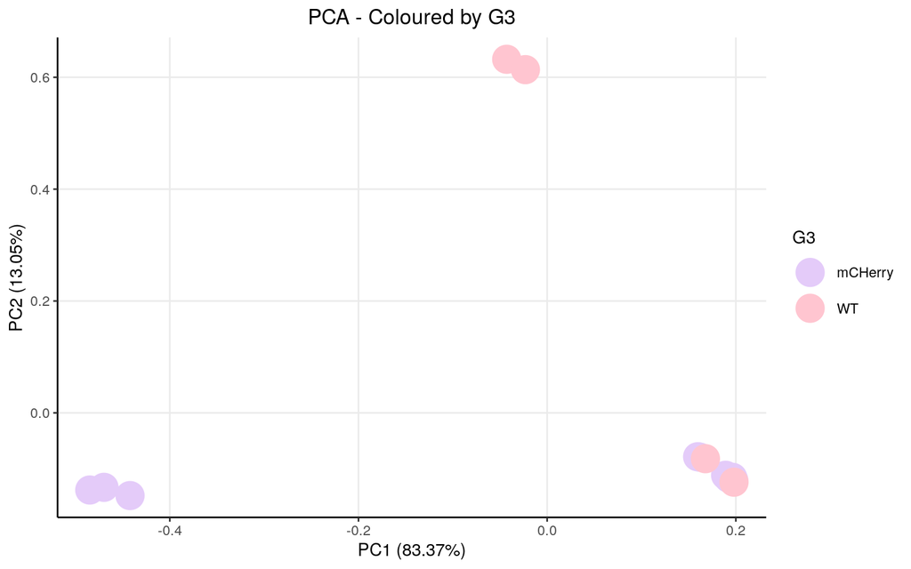

```r
p_g3
```

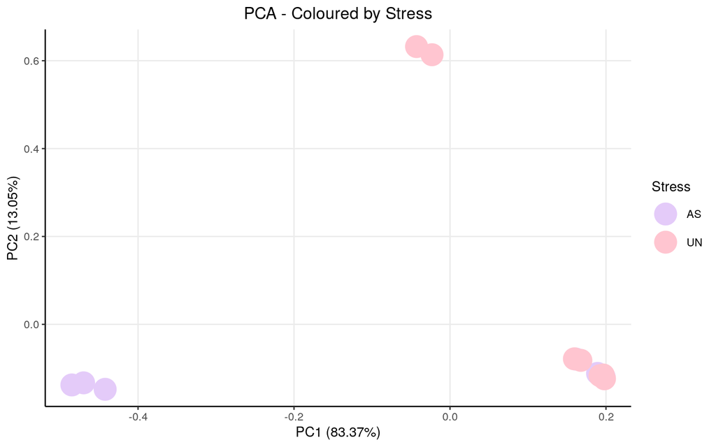

```r
p_Stress
```

```r
#in case you want to see most important genes for PCA yourself
contribs1 <- pca_res$rotation[,1]
contribs2 <- pca_res$rotation[,2]

#These are the biggest contributors to the PCA1 (right side)
(pos1genes <- sort(contribs1, decreasing=T)[1:10])
```

```
##     MT-ND5     MT-ND6     MT-ND4     MT-CYB     MT-CO2     MT-CO3     MT-ND2
## 0.06883891 0.06541250 0.06535012 0.06529969 0.06401375 0.06132311 0.06052585
##     MT-CO1    MT-ND4L    MT-ATP6
## 0.06039604 0.05980745 0.05918833
```

```r
#These are the biggest contributors to the PCA1 (left side)
(neg1genes <- sort(contribs1, decreasing=F)[1:10])
```

```
##        RO60      GTF2A1      ZBTB41       BNIP2      SSX2IP        CDK6
## -0.02727778 -0.02671564 -0.02581008 -0.02538345 -0.02490891 -0.02481602
##       SYPL1       RRM2B      ZNF770      ZBTB33
## -0.02457847 -0.02410224 -0.02392460 -0.02389842
```

```r
#These are the biggest contributors to the PCA2 (up side)
(pos2genes <- sort(contribs2, decreasing=T)[1:10])
```

```
##     LIMCH1      CSPP1    FAM111B       PAX6      MECOM      TDRD3       PRTG
## 0.06144779 0.04910752 0.04718123 0.04661078 0.04448892 0.04314550 0.04307433
##      ZFP30     ZNF566     ZBTB43
## 0.04104523 0.04090898 0.04083488
```

```r
#These are the biggest contributors to the PCA2 (down side)
(neg2genes <- sort(contribs2, decreasing=F)[1:10])
```

```
##       CNNM4        UPF1       IGF2R       MXRA7        LRBA       PRKDC
## -0.03964404 -0.03947093 -0.03851631 -0.03788517 -0.03755869 -0.03672955
##       ZMIZ1      SEC16A     BHLHE40        TNS1
## -0.03653528 -0.03645314 -0.03638399 -0.03628437
```

After batch correction, as one can observe from the PCAs, our PC1 is now explained by sample type.

# PB vs SG DC

## Linear Models

Now we must perform linear model fitting.

```r
fitted <- lmFit(y, mm)
head(coef(fitted))
```

```
##       SamplePB SampleSG  SampleWC
## AAAS  7.490182 6.558441  8.016423
## AACS  5.968298 5.499641  7.152559
## AAGAB 6.593747 6.733712  6.625531
## AAMP  7.227775 6.474268  7.786273
## AAR2  6.915393 6.714185  7.392546
## AARS1 8.872417 9.753778 10.078253
```

```r
#next we measure contrasts between groups (log-fold change is obtained from these fitted linear models)
contr<- makeContrasts(SampleSG          - SampleWC, levels = colnames(coef(fitted)))

#next we estimate the contrast for each gene
tmp <- contrasts.fit(fitted, contr)


#use empirical bayes smoothing of standard erros (shrinks extreme standard erros)
tmp <- eBayes(tmp)
top.table <- topTable(tmp, sort.by = "logFC", n = Inf)
DEGenes <- top.table
ndegs=20
```

## Volcano

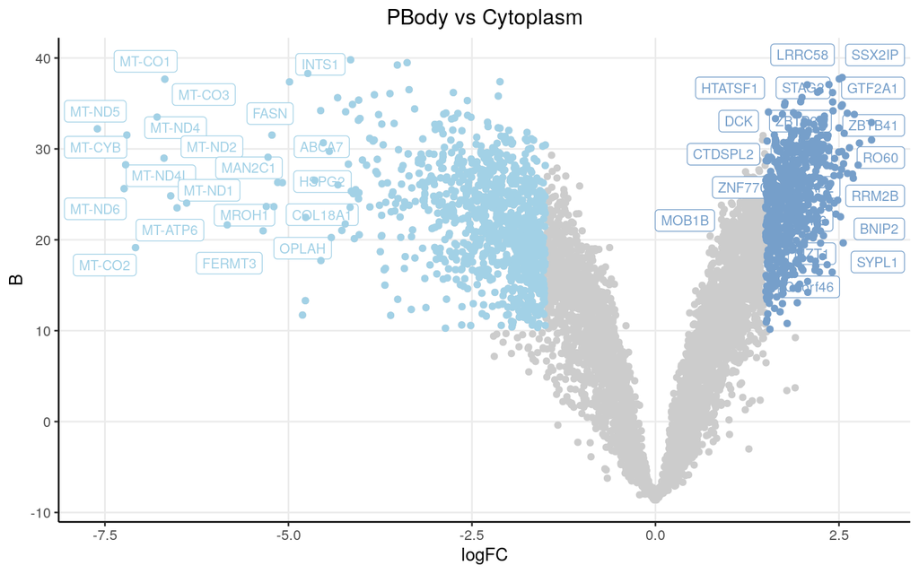

```r
upmarkers <- as.data.frame(DEGenes[DEGenes$logFC>1.5 & DEGenes$B>10,] )
downmarkers <- as.data.frame(DEGenes[DEGenes$logFC< -1.5 & DEGenes$B>10,] )

ggplot(data=DEGenes,
                 aes(x=logFC,
                     y=  B)) +
  geom_point(color="#CCCCCC")+
  theme_bw() +
  theme(axis.line = element_line(colour = "black"),
        panel.grid.minor = element_blank(),
        panel.border = element_blank(),
        panel.background = element_blank()) +
  ggtitle("PBody vs Cytoplasm")+
  theme(plot.title = element_text(hjust = 0.5)) +
  geom_label_repel(upmarkers[1:ndegs,] , mapping=aes(label=row.names(upmarkers)[1:ndegs]),size=3,point.padding=-0.5, color="#769fca",max.overlaps = 20)+
  geom_label_repel(downmarkers[1:ndegs,] , mapping=aes(label=row.names(downmarkers)[1:ndegs]),size=3,point.padding=-0.5, color="#a2d1e6",max.overlaps = 20)+
  geom_point(data=upmarkers, aes(x=logFC, y=  B), color="#769fca")+
  geom_point(data=downmarkers, aes(x=logFC, y=  B), color="#a2d1e6")
```

```r
sg_t <- data.frame(Gene=row.names(DEGenes), sg_t=DEGenes$t)
```

# PB vs SG Fanci

## Linear Models

Now we must perform linear model fitting.

```r
fitted <- lmFit(y, mm)
head(coef(fitted))
```

```
##       SamplePB SampleSG  SampleWC
## AAAS  7.490182 6.558441  8.016423
## AACS  5.968298 5.499641  7.152559
## AAGAB 6.593747 6.733712  6.625531
## AAMP  7.227775 6.474268  7.786273
## AAR2  6.915393 6.714185  7.392546
## AARS1 8.872417 9.753778 10.078253
```

```r
#next we measure contrasts between groups (log-fold change is obtained from these fitted linear models)
contr<- makeContrasts(SamplePB           - SampleWC, levels = colnames(coef(fitted)))

#next we estimate the contrast for each gene
tmp <- contrasts.fit(fitted, contr)


#use empirical bayes smoothing of standard erros (shrinks extreme standard erros)
tmp <- eBayes(tmp)
top.table <- topTable(tmp, sort.by = "logFC", n = Inf)
DEGenes <- top.table
ndegs=20
```

## Volcano

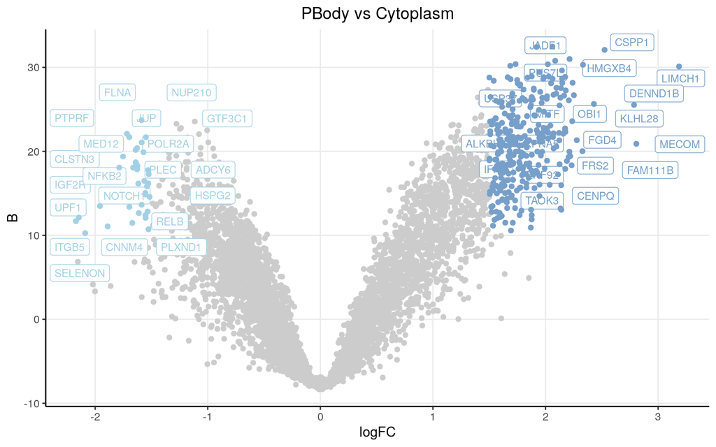

```r
upmarkers <- as.data.frame(DEGenes[DEGenes$logFC>1.5 & DEGenes$B>10,] )
downmarkers <- as.data.frame(DEGenes[DEGenes$logFC< -1.5 & DEGenes$B>10,] )

ggplot(data=DEGenes,
                 aes(x=logFC,
                     y=  B)) +
  geom_point(color="#CCCCCC")+
  theme_bw() +
  theme(axis.line = element_line(colour = "black"),
        panel.grid.minor = element_blank(),
        panel.border = element_blank(),
        panel.background = element_blank()) +
  ggtitle("PBody vs Cytoplasm")+
  theme(plot.title = element_text(hjust = 0.5)) +
  geom_label_repel(upmarkers[1:ndegs,] , mapping=aes(label=row.names(upmarkers)[1:ndegs]),size=3,point.padding=-0.5, color="#769fca",max.overlaps = 20)+
  geom_label_repel(downmarkers[1:ndegs,] , mapping=aes(label=row.names(downmarkers)[1:ndegs]),size=3,point.padding=-0.5, color="#a2d1e6",max.overlaps = 20)+
  geom_point(data=upmarkers, aes(x=logFC, y=  B), color="#769fca")+
  geom_point(data=downmarkers, aes(x=logFC, y=  B), color="#a2d1e6")
```

```r
pb_t <- data.frame(Gene=row.names(DEGenes), pb_t=DEGenes$t)
```

# Comparisons

Comparing the methods once again.

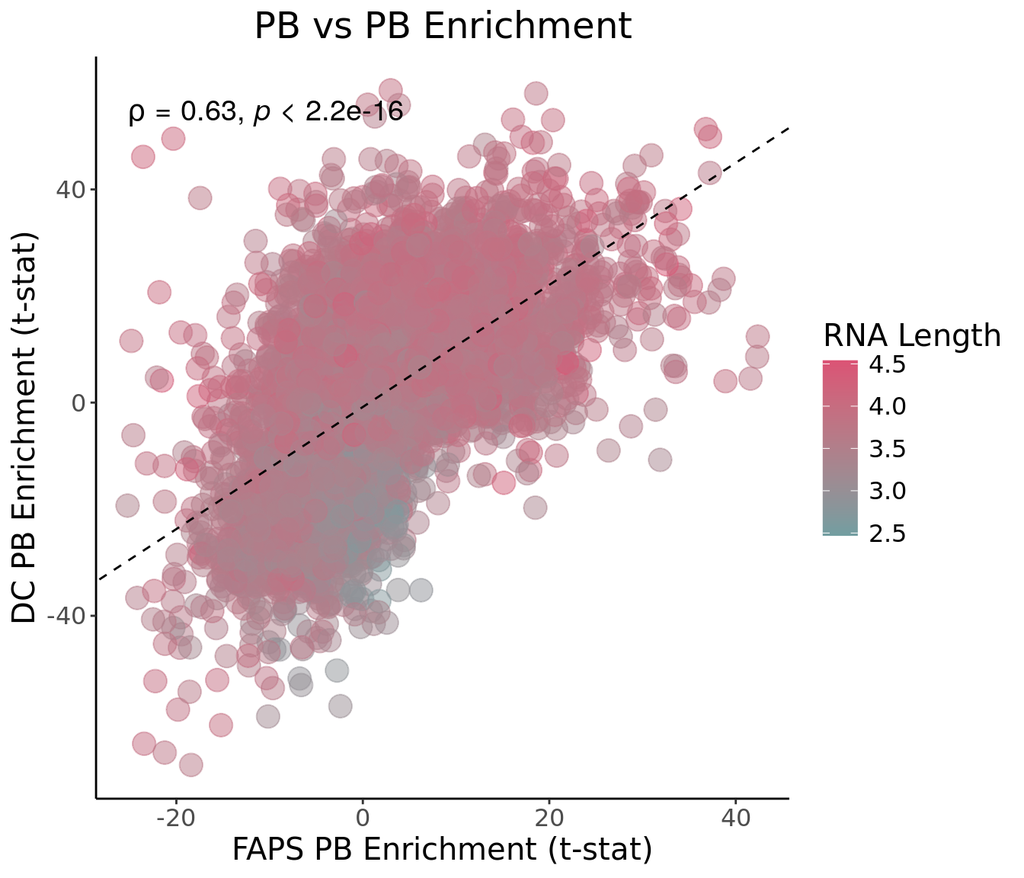

```r
tstable <- merge(sg_t, pb_t, by="Gene")
tstable <- merge(tstable, genelength, by="Gene")
smooth.SG <- lm(sg_t~(pb_t), tstable)

# Calculate the Spearman correlation coefficient
spearman_corr <- cor(tstable$sg_t, (tstable$pb_t), method = "spearman")

ggplot(tstable, aes(y=sg_t, x=(pb_t))) + geom_point(aes(color=log10(Length)), alpha=0.5, size=5) +   theme_bw()+
 ylab("DC PB Enrichment (t-stat)") + xlab("FAPS PB Enrichment (t-stat)") + scale_colour_gradient(low="black", high = "Red")+
  theme(axis.line = element_line(colour = "black"),
        panel.grid.minor = element_blank(),
        panel.border = element_blank(),
        panel.background = element_blank()) +
  geom_abline(slope=smooth.SG$coefficients[2], intercept = smooth.SG$coefficients[1], linetype = "dashed")+
  theme(plot.title = element_text(hjust = 0.5))  + ggtitle("PB vs PB Enrichment")+
  scale_colour_gradient(low="#729EA1", high = "#DB5375")+
  labs(colour = "RNA Length") + stat_cor(method = "spearman", cor.coef.name = "rho", size=5)+ theme(panel.grid.major = element_blank(), panel.grid.minor = element_blank())+theme(text=element_text(size=15,  family="Arial MS"))
```

```r
write.table(tstable,"~/Projects/StressGranules/SGPAPER/FAPSPB_batchCor.txt")
```

[^1]: Disease Transcriptomics Group, Gulbenkian Institute of Molecular Medicine